```python
%pip install fncbook
import fncbook as FNC
```

# NumPy

```python
import numpy as np
print("NumPy version:", np.__version__)
```

```
NumPy version: 2.2.5
```

```python
# Creating arrays from lists
arr1 = np.array([1, 2, 3, 4, 5])
print("Array from list:", arr1)


# 2D array (matrix)
arr2 = np.array([[1, 2, 3], [4, 5, 6]])
print("\n2D array (matrix):\n", arr2)


# Special arrays
zeros = np.zeros((3, 3))
ones = np.ones((2, 4))
identity = np.eye(3)
diagonal = np.diag([-1, 1, -5])

print("\nZeros:\n", zeros)
print("\nOnes:\n", ones)
print("\nIdentity matrix:\n", identity)
print("\nDiagonal matrix:\n", diagonal)
```

```
Array from list: [1 2 3 4 5]

2D array (matrix):
 [[1 2 3]
 [4 5 6]]

Zeros:
 [[0. 0. 0.]
 [0. 0. 0.]
 [0. 0. 0.]]

Ones:
 [[1. 1. 1. 1.]
 [1. 1. 1. 1.]]

Identity matrix:
 [[1. 0. 0.]
 [0. 1. 0.]
 [0. 0. 1.]]

Diagonal matrix:
 [[-1  0  0]
 [ 0  1  0]
 [ 0  0 -5]]
```

```python
# Range and linspace
rng = np.arange(0, 10, 2)
lin = np.linspace(0, 1, 5)
print("\nRange with step (arange):", rng)
print("Linearly spaced values (linspace):", lin)
```

```
Range with step (arange): [0 2 4 6 8]
Linearly spaced values (linspace): [0.   0.25 0.5  0.75 1.  ]
```

```python
print("\nShape of arr2:", arr2.shape)
print("Dimensions (ndim):", arr2.ndim)
print("Number of elements (size):", arr2.size)
print("Data type (dtype):", arr2.dtype)
print("Item size (bytes per element):", arr2.itemsize)
```

```
Shape of arr2: (2, 3)
Dimensions (ndim): 2
Number of elements (size): 6
Data type (dtype): int64
Item size (bytes per element): 8
```

```python
# Reshaping
A = np.arange(1, 13).reshape(3, 4)
print("\nMatrix A (reshaped 1-12 into 3x4):\n", A)
```

```
Matrix A (reshaped 1-12 into 3x4):
 [[ 1  2  3  4]
 [ 5  6  7  8]
 [ 9 10 11 12]]
```

```python
# Indexing and slicing
print("First row:", A[0])
print("Element at row 2, col 3:", A[1, 2])
print("First two rows:\n", A[:2])
print("Last column:\n", A[:, -1])
```

```
First row: [1 2 3 4]
Element at row 2, col 3: 7
First two rows:
 [[1 2 3 4]
 [5 6 7 8]]
Last column:
 [ 4  8 12]
```

```python
print( np.hstack([A, A]) )
print("\n")
print( np.vstack([A, A]) )
```

```
[[ 1  2  3  4  1  2  3  4]
 [ 5  6  7  8  5  6  7  8]
 [ 9 10 11 12  9 10 11 12]]


[[ 1  2  3  4]
 [ 5  6  7  8]
 [ 9 10 11 12]
 [ 1  2  3  4]
 [ 5  6  7  8]
 [ 9 10 11 12]]
```

```python
print(A+1j)
print((A+1j).conj())
```

```
[[ 1.+1.j  2.+1.j  3.+1.j  4.+1.j]
 [ 5.+1.j  6.+1.j  7.+1.j  8.+1.j]
 [ 9.+1.j 10.+1.j 11.+1.j 12.+1.j]]
[[ 1.-1.j  2.-1.j  3.-1.j  4.-1.j]
 [ 5.-1.j  6.-1.j  7.-1.j  8.-1.j]
 [ 9.-1.j 10.-1.j 11.-1.j 12.-1.j]]
```

```python
print(A[1:3, 0:2])    # rows 2 and 3, cols 1 and 2
print(A[1:])  # rows 2 through the end
print(A[:2, 0])  # first two rows in column 1
print(A[::2])  # all the odd rows
print(A[:, ::-1])  # reverse the columns
```

```
[[ 5  6]
 [ 9 10]]
[[ 5  6  7  8]
 [ 9 10 11 12]]
[1 5]
[[ 1  2  3  4]
 [ 9 10 11 12]]
[[ 4  3  2  1]
 [ 8  7  6  5]
 [12 11 10  9]]
```

```python
print(A**2)
print(2**A)
print(np.cos(np.pi*A))
```

```
[[  1   4   9  16]
 [ 25  36  49  64]
 [ 81 100 121 144]]
[[   2    4    8   16]
 [  32   64  128  256]
 [ 512 1024 2048 4096]]
[[-1.  1. -1.  1.]
 [-1.  1. -1.  1.]
 [-1.  1. -1.  1.]]
```

```python
# Boolean indexing
mask = A > 5
print("\nMask where A > 5:\n", mask)
print("Values > 5:", A[mask])
```

```
Mask where A > 5:
 [[False False False False]
 [False  True  True  True]
 [ True  True  True  True]]
Values > 5: [ 6  7  8  9 10 11 12]
```

```python
# Useful ndarray methods
print("\nSum of all elements:", A.sum())
print("Column-wise mean:", A.mean(axis=0))
print("Row-wise max:", A.max(axis=1))
```

```
Sum of all elements: 78
Column-wise mean: [5. 6. 7. 8.]
Row-wise max: [ 4  8 12]
```

```python
# Basic elementwise and matrix operations
B = np.array([[5, 6, 7, 8], [1, 2, 3, 4], [9, 10, 11, 12]])

print("\nMatrix A:\n", A)
print("Matrix B:\n", B)

print("\nA+B:\n", A+B)
print("A-B:\n", A-B)
print("Transpose:\n", A.T)
print("Elementwise multiplication:\n", A*B)
print("Elementwise square of A:\n", A**2)
print("Matrix multiplication (A @ B^T):\n", A @ B.T)
```

```
Matrix A:
 [[ 1  2  3  4]
 [ 5  6  7  8]
 [ 9 10 11 12]]
Matrix B:
 [[ 5  6  7  8]
 [ 1  2  3  4]
 [ 9 10 11 12]]

A+B:
 [[ 6  8 10 12]
 [ 6  8 10 12]
 [18 20 22 24]]
A-B:
 [[-4 -4 -4 -4]
 [ 4  4  4  4]
 [ 0  0  0  0]]
Transpose:
 [[ 1  5  9]
 [ 2  6 10]
 [ 3  7 11]
 [ 4  8 12]]
Elementwise multiplication:
 [[  5  12  21  32]
 [  5  12  21  32]
 [ 81 100 121 144]]
Elementwise square of A:
 [[  1   4   9  16]
 [ 25  36  49  64]
 [ 81 100 121 144]]
Matrix multiplication (A @ B^T):
 [[ 70  30 110]
 [174  70 278]
 [278 110 446]]
```

```python
# Broadcasting
v = np.array([1, 2, 3, 4])
print("\nBroadcast row vector v across A:\n", A + v)
```

```
Broadcast row vector v across A:
 [[ 2  4  6  8]
 [ 6  8 10 12]
 [10 12 14 16]]
```

```python
# Linear algebra operations
from numpy.linalg import inv, det, solve, norm
```

```python
M = np.array([[1, 2], [3, 4]])
print("\nMatrix M:\n", M)

print("Norm of M:", norm(M))
print("Determinant of M:", det(M))
print("Inverse of M:\n", inv(M))


b = np.array([1, 2])
x = solve(M, b)
print("Solution to Mx=b:", x)
```

```
Matrix M:
 [[1 2]
 [3 4]]
Norm of M: 5.477225575051661
Determinant of M: -2.0000000000000004
Inverse of M:
 [[-2.   1. ]
 [ 1.5 -0.5]]
Solution to Mx=b: [0.  0.5]
```

```python
# Gram–Schmidt orthogonalization
def gram_schmidt(vectors):
  """Orthonormalize a set of vectors using the Gram-Schmidt process."""
  vectors = [np.array(v, dtype=float) for v in vectors]
  ortho = []
  for v in vectors:
    w = v - sum(np.dot(v, u)*u for u in ortho)
    if norm(w) > 1e-10:
      ortho.append(w / norm(w))
  return np.array(ortho)


V = np.array([[1,1,0],[1,0,1],[0,1,1]])
Q = gram_schmidt(V)
print("\nOriginal vectors:\n", V)
print("\nOrthonormal basis (Gram–Schmidt):\n", Q)
print("Check orthogonality (Q^T Q):\n", Q.T @ Q)
```

```
Original vectors:
 [[1 1 0]
 [1 0 1]
 [0 1 1]]

Orthonormal basis (Gram–Schmidt):
 [[ 0.70710678  0.70710678  0.        ]
 [ 0.40824829 -0.40824829  0.81649658]
 [-0.57735027  0.57735027  0.57735027]]
Check orthogonality (Q^T Q):
 [[ 1.00000000e+00 -2.19098475e-16  2.50753550e-16]
 [-2.19098475e-16  1.00000000e+00  4.39774161e-17]
 [ 2.50753550e-16  4.39774161e-17  1.00000000e+00]]
```

## Exercise 1

(a) Let

$$ A = \begin{pmatrix} 1 & 3 \\ 2 & -1 \end{pmatrix}, \quad B = \begin{pmatrix} 1 & 0 & -3 \\ 4 & 1 & 2 \end{pmatrix}, $$$$ C = \begin{pmatrix} 1 & 1 & 4 \\ -1 & -2 & 0 \end{pmatrix}, \quad D = \begin{pmatrix} 2 \\ -2 \\ 3 \end{pmatrix}. $$

Compute

$$ A(2B + 3C), \quad (AB)D, \quad \text{and} \quad A(BD). $$

(b) Let

$$ A = \begin{pmatrix} 2 & 5 \\ -3 & 1 \\ 4 & 2 \end{pmatrix}, \quad B = \begin{pmatrix} 3 & -2 & 0 \\ 1 & -1 & 4 \\ 5 & 5 & 3 \end{pmatrix}, \quad C = \begin{pmatrix} 4 & 0 & 3 \end{pmatrix}. $$

Compute

$$ A^t, \quad A^tB, \quad BC^t, \quad CB, \quad \text{and} \quad CA. $$

Linear Algebra, Fourth Edition, Stephen H. Friedberg, Arnold J. Insel, Lawrence E. Spence

2.3 Exercises 2

#### Part (a)

```python
# Import
import numpy as np

# Code
A = np.array([[1, 3], [2, -1]])
B = np.array([[1, 0, -3], [4, 1, 2]])
C = np.array([[1, 1, 4], [-1, -2, 0]])
D = np.array([[2], [-2], [3]])

print(f"A(2B + 3C)\n{A @ (2 * B + 3 * C)}\n")
print(f"(AB)D\n{(A @ B) @ D}\n")
print(f"A(BD)\n{A @ (B @ D)}\n")
```

```
A(2B + 3C)
[[20 -9 18]
 [ 5 10  8]]

(AB)D
[[ 29]
 [-26]]

A(BD)
[[ 29]
 [-26]]
```

#### Part (b)

```python
# Import
import numpy as np

# Code
A = np.array([[2, 5], [-3, 1], [4, 2]])
B = np.array([[3, -2, 0], [1, -1, 4], [5, 5, 3]])
C = np.array([[4, 0, 3]])

print(f"A^T\n{A.T}\n")
print(f"A^T B \n{A.T @ B}\n")
print(f"BC^T\n{B @ C.T}\n")
print(f"CB\n{C @ B}\n")
print(f"CA\n{C @ A}\n")
```

```
A^T
[[ 2 -3  4]
 [ 5  1  2]]

A^T B
[[23 19  0]
 [26 -1 10]]

BC^T
[[12]
 [16]
 [29]]

CB
[[27  7  9]]

CA
[[20 26]]
```

# Problems and conditioning

The polynomial

$$p(x) = \frac{1}{3}(x-1)(x-1-\epsilon)$$

has roots 1 and 1+ϵ. For small values of ϵ, the roots are ill-conditioned.

```python
ep = 1e-6
a, b, c = 1/3, (-2 - ep) / 3, (1 + ep) / 3   # coefficients of p
```

Here are the roots as computed by the quadratic formula.

```python
d = np.sqrt(b**2 - 4*a*c)
r1 = (-b - d) / (2*a)
r2 = (-b + d) / (2*a)
print(r1, r2)
```

```
0.9999999998251499 1.0000010001748503
```

The display of r2 suggests that the last five digits or so are inaccurate. The relative error in the value is

```python
print(abs(r1 - 1) / abs(1))
print(abs(r2 - (1 + ep)) / abs(1 + ep))
```

```
1.7485013437124053e-10
1.748501815656639e-10
```

The condition number of each root is $$\kappa(\mathbf{r}_i) = \frac{|\mathbf{r}_i|}{|\mathbf{r}_1 - \mathbf{r}_2|} \approx \frac{1}{\epsilon}$$ Thus, relative error in the data at the level of roundoff can grow in the result to be roughly

```python
print(np.finfo(float).eps / ep)
```

```
2.220446049250313e-10
```

This matches the observation pretty well.

# Stability of algorithms

## Writing your own functions:

```python
def myfun_1(x):
  s = np.exp(np.cos(x))
  return s

myfun_2 = lambda x : np.exp(np.cos(x))

print(myfun_1(np.pi))
print(myfun_2(np.pi))
```

```
0.36787944117144233
0.36787944117144233
```

### Exercise 2

Implement a function F(n) that takes a positive integer n as input and returns the n-th term of the Fibonacci sequence.

Note: Do not use any external libraries (e.g., math, numpy).

```python
# Define F
def F(n):
    if (n == 1):
        return 1

    prev = 0
    curr = 1

    while (n > 1):
        next = curr + prev
        prev = curr
        curr = next
        n -= 1

    return next
```

```python
# Test F
print(f"F(1) = {F(1)}; F(2) = {F(2)}; F(3) = {F(3)}; F(4) = {F(4)}; F(7) = {F(7)}")
```

```
F(1) = 1; F(2) = 1; F(3) = 2; F(4) = 3; F(7) = 13
```

### Exercise 3

Implement a function that takes a list of positive integers as input and returns the least common multiple (LCM) of all the elements in the array.

Note: Do not use any external libraries (e.g., math, numpy).

```python
# Needed other functions
def gcd(a, b): # Euclidean
    while b:
        a, b = b, a % b
    return a

# Code for LCM
def lcm(list):
    if not list:
        return 1

    tot_lcm = 1
    for i in range(len(list)):
        tot_lcm = (tot_lcm * list[i]) / gcd(tot_lcm, list[i]) # LCM(tot_lcm, list[i])

    return tot_lcm
```

```python
# Test LCM
print(f"LCM([2, 3, 7, 15]) = {lcm([2, 3, 7, 15])}")
```

```
LCM([2, 3, 7, 15]) = 210.0
```

## Case: finding the roots of a quadratic polynomial

We apply the quadratic formula to find the roots of a quadratic $$p(x) = (x-10^{6})(x-10^{-6})$$

```python
a = 1;  b = -(1e6 + 1e-6);  c = 1;
x1 = (-b + np.sqrt(b**2 - 4*a*c)) / 2*a
x2 = (-b - np.sqrt(b**2 - 4*a*c)) / 2*a
print(x1)
print(x2)
```

```
1000000.0
1.00000761449337e-06
```

The first value is correct to all stored digits, but the second has fewer than six accurate digits:

```python
error = abs(1e-6 - x2) / 1e-6
print(f"There are {-np.log10(error):.2f} accurate digits.")
```

```
There are 5.12 accurate digits.
```

The instability is easily explained. Since a=c=1, we treat them as exact numbers. First, we compute the condition numbers with respect to b for each elementary step in finding the “good” root: \begin{array}{|l|l|l|} \hline \textbf{Calculation} & \textbf{Result} & \boldsymbol{\kappa} \\ \hline u_1 = b^2 & 1.000000000002000 \times 10^{12} & 2 \\ u_2 = u_1 - 4 & 9.999999999980000 \times 10^{11} & \approx 1.00 \\ u_3 = \sqrt{u_2} & 999999.9999990000 & 1/2 \\ u_4 = u_3 - b & 2000000 & \approx 0.500 \\ u_5 = u_4 / 2 & 1000000 & 1 \\ \hline \end{array}

Using (1.2.9), the chain rule for condition numbers, the conditioning of the entire chain is the product of the individual steps, so there is essentially no growth of relative error here. However, if we use the quadratic formula for the “bad” root, the next-to-last step becomes $$ u_4 = (-u_3) - b, $$ and now $$ \kappa = \frac{|u_3|}{|u_4|} \approx 5 \times 10^{11}. $$ So we can expect to lose 11 digits of accuracy, which is what we observed. The key issue is the subtractive cancellation in this one step.

Another algorithm

```python
a = 1
b = -(1e6 + 1e-6)
c = 1
x1 = (-b + np.sqrt(b**2 - 4*a*c)) / 2*a
x2 = c / (a * x1)
print(x1)
print(x2)
print(abs(x2 - 1e-6) / 1e-6)
```

```
1000000.0
1e-06
0.0
```

### Exercise 4

Find κ when:

a = 1; b = -(1e8 + 1e-8); c = 1;

a = 1; b = -(1e10 + 1e-10); c = 1;

Then, explain what you observe.

From the examples above under the similar circumstances, we notice $\kappa = \frac{|u_3|}{|u_4|}$, where $u_3 = \sqrt{b^2 - 4}$, and $u_4 = u_3 - b$ for the "good" root, and for the bad root it's $u'_4 = -u_3 - b$.

In faact, we can attempt to calculate $\kappa_1$ and $\kappa_2$ using Python, for both the good and bad roots

```python
# Code for Exercise 4

import math

def kappa(b, good_root):
    try:
        value = abs(math.sqrt(b ** 2 - 4) / ((1 if good_root else -1) * math.sqrt(b ** 2 - 4) - b))
        return value
    except Exception as e:
        return e

# Print
print(f"First good kappa = {kappa(-(1e8 + 1e-8), True)}")
print(f"First bad kappa = {kappa(-(1e8 + 1e-8), False)}")
print(f"Second good kappa = {kappa(-(1e10 + 1e-10), True)}")
print(f"Second bad kappa = {kappa(-(1e10 + 1e-10), False)}")
```

```
First good kappa = 0.49999999999999994
First bad kappa = 3355443199999999.5
Second good kappa = 0.5
Second bad kappa = float division by zero
```

Notice, the "good" roots have $\kappa$ roughly at 0.5. At the "bad" roots, the $\kappa$ starts to be lss stable due to the fact that the denominator is closer to zero. The second bad kappa in fact has the error "division by zero".

## Backward error:

Our first step is to construct a polynomial with six known roots.

```python
r = [-2, -1, 1, 1, 3, 6]
p = np.poly(r)
print(p)
```

```
[  1.  -8.   6.  44. -43. -36.  36.]
```

Now we use a standard numerical method for finding those roots, pretending that we don’t know them already.

```python
r_computed = np.sort(np.roots(p))
print(r_computed)
```

```
[-2.         -1.          0.99999999  1.00000001  3.          6.        ]
```

Here are the relative errors in each of the computed roots.

```python
print(abs(r - r_computed) / r)
```

```
[-3.33066907e-16 -2.22044605e-16  1.23542254e-08  1.23542241e-08
  1.18423789e-15  1.18423789e-15]
```

It seems that the forward error is acceptably close to machine epsilon for double precision in all cases except the double root at x=1. This is not a surprise, though, given the poor conditioning at such roots.

Let’s consider the backward error. The data in the rootfinding problem is the polynomial coefficients. We can apply poly to find the coefficients of the polynomial (that is, the data) whose roots were actually computed by the numerical algorithm.

```python
p_computed = np.poly(r_computed)
print(p_computed)
```

```
[  1.  -8.   6.  44. -43. -36.  36.]
```

We find that in a relative sense, these coefficients are very close to those of the original, exact polynomial:

```python
print(abs(p - p_computed) / p)
```

```
[ 0.00000000e+00 -5.55111512e-16  4.44089210e-16  3.22973971e-16
 -1.48718247e-15 -1.97372982e-16  1.57898386e-15]
```

In summary, even though there are some computed roots relatively far from their correct values, they are nevertheless the roots of a polynomial that is very close to the original.

### Exercise 5

Can you construct a polynomial that leads to large computational errors when finding its roots (in terms of forward or backward error)? Find the errors and explain why they occur.

#### **Forward Error Example**

```python
# Import
import numpy as np

# Forward error example
r = [-1e14+0.4, -1e14+0.4, 1e-14, 1e-14]
p = np.poly(r)
print("Polynomial:", p)

r_computed = np.sort(np.roots(p))
print("New Roots:", r_computed)

print("Relative Error:", abs(r - r_computed) / r)
```

```
Polynomial: [ 1.e+00  2.e+14  1.e+28 -2.e+14  1.e+00]
New Roots: [-1.00000000e+14-1286321.55392366j -1.00000000e+14+1286321.55392366j
  9.99999989e-15      +0.j          1.00000001e-14      +0.j        ]
Relative Error: [-1.28632155e-08 -1.28632155e-08  1.05879115e-08  1.05879122e-08]
```

As the chosen roots have very large magnitudes $(\approx 10^{14})$ and very small ones $(\approx 10^{-14})$, the resulting polynomial coefficients span many orders of magnitude. This makes the polynomial highly ill-conditioned. Additionally, adding repeated roots amplifies sensitivity: tiny perturbations in the coefficients, which are unavoidable in floating-point arithmetic, can cause the computed roots to shift significantly. Hence, the algorithm produces large forward errors in the roots, even though the backward error remains small.

#### **Backward Error Example**

```python
# Backward Error Example
# Imoort
import numpy as np

# Compute the polynomial
r = [-1e-16, 1e-16, 1-1e8, 1+1e8]
p = np.poly(r)
print("Polynomial:", p)

r_computed = np.sort(np.roots(p))

# Backward error
p_computed = np.poly(r_computed)
print("Backward polynomial:", p_computed)
print("Backward error:", abs(p - p_computed) / p)
```

```
Polynomial: [ 1.00000000e+00 -2.00000000e+00 -1.00000000e+16  2.00000001e-32
  1.00000000e-16]
Backward polynomial: [ 1.00000000e+00 -1.99999999e+00 -1.00000000e+16  0.00000000e+00
  0.00000000e+00]
Backward error: [ 0.0000000e+00 -7.4505806e-09 -0.0000000e+00  1.0000000e+00
  1.0000000e+00]
```

Here, we created the example of a polynomial with high backward error, up to $1$. This is done via getting nearby roots differing by a small margin, including $-\varepsilon_{mach}$ and $\varepsilon_{mach}$, while also including large contrasting roots such as $1-10^8$ and $1 + 10^8$. Then, when multiplying the roots to form the polynomial, these form coefficients with order of magnitude $\varepsilon_{mach}$. As the terms will be negligible when computing the roots of the polynomial, it causes huge backward error.

# Numpy exercises

## Exercise 6

Estimate π using Monte Carlo simulation with 1 million random points.

```python
import numpy as np

N = 1_000_000

# Generate square of [0, 1] x [0, 1]
x = np.random.rand(N)
y = np.random.rand(N)

inside = np.sum(x**2 + y**2 <= 1) # Radius 1 but first quadrant, so area = pi / 4

pi_est = 4 * inside / N
print(f"Pi estimate is {pi_est}")
```

```
Pi estimate is 3.141392
```

## Exercise 7

Approximate the integral of $f(x)=\sin(x^2)$ over [0, 2] using the trapezoidal rule with 1000 points.

```python
import numpy as np
import math

# Method 1
# area = 0
# intervals = np.linspace(0, 2, 1000)
# for i in range (999):
#     area += 1 / 2 * (intervals[i + 1] - intervals[i]) * (math.sin(intervals[i + 1] ** 2) + math.sin(intervals[i] ** 2))

# Alternatively
x = np.linspace(0, 2, 1000)
y = np.sin(x**2)
area = np.trapezoid(y, x) # NumPy built-in trapezoid rule

print(f"Estimated value for the integral = {area}")
```

```
Estimated value for the integral = 0.8047756160719219
```

## Exercise 8

Given a matrix $A$, determine if it's diagonalizable. If it is, find the diagonal matrix $D$ and the matrix $P$ such that $𝐴=𝑃𝐷𝑃^{−1}$, and verify the result.

```python
import numpy as np

# Example matrix
A = np.array([[5, 4],
              [1, 2]], dtype=float)

# Compute eigenvalues and eigenvectors
eigvals, eigvecs = np.linalg.eig(A)

# Form diagonal matrix D
D = np.diag(eigvals)

# P is the matrix of eigenvectors
P = eigvecs

# Check if P is invertible (i.e., eigenvectors are linearly independent)
if np.linalg.matrix_rank(P) == A.shape[0]:
    print("A is diagonalizable.")
    print("D =\n", D)
    print("P =\n", P)

    # Verify: A ≈ P D P^{-1}
    A_reconstructed = P @ D @ np.linalg.inv(P)
    print("Reconstructed A =\n", A_reconstructed)
    print("Difference =\n", A - A_reconstructed)
else:
    print("A is NOT diagonalizable.")
```

```
A is diagonalizable.
D =
 [[6. 0.]
 [0. 1.]]
P =
 [[ 0.9701425  -0.70710678]
 [ 0.24253563  0.70710678]]
Reconstructed A =
 [[5. 4.]
 [1. 2.]]
Difference =
 [[0.00000000e+00 4.44089210e-16]
 [1.11022302e-16 0.00000000e+00]]
```

## Exercise 9

Fit a line to data points using least squares (without using np.polyfit).

```python
# The best fit line is beta = (X^T X)^-1 X^T Y
import numpy as np

# Example data
x = np.array([0, 1, 2, 3, 4], dtype=float)
y = np.array([1, 2, 1.3, 3.75, 2.5], dtype=float)

# Build design matrix X = [[1, x_i]]
X = np.vstack([np.ones(len(x)), x]).T

# Solve normal equations: beta = (X^T X)^(-1) X^T y
beta = np.linalg.inv(X.T @ X) @ (X.T @ y)

b, m = beta  # intercept, slope
print(f"Slope = {m}, Intercept = {b}")

# Predicted values
y_fit = X @ beta
```

```
Slope = 0.475, Intercept = 1.1600000000000004
```

## Exercise 10

Verify the Cayley-Hamilton theorem for a 3×3 matrix: show that it satisfies its own characteristic equation.

```python
import numpy as np

# Example 3x3 matrix
A = np.array([[2, -1, 0],
              [1,  2, 1],
              [0, -1, 2]], dtype=float)

# Characteristic polynomial coefficients
# np.poly gives highest degree first: [1, c2, c1, c0]
coeffs = np.poly(A)
print("Characteristic polynomial coefficients:", coeffs)

# Expand p(A) = A^3 + c2*A^2 + c1*A + c0*I
n = A.shape[0]
pA = (coeffs[0] * np.linalg.matrix_power(A, 3) +
      coeffs[1] * np.linalg.matrix_power(A, 2) +
      coeffs[2] * A +
      coeffs[3] * np.eye(n))

print("p(A) =\n", pA)
print("Is p(A) approximately zero? ->", np.allclose(pA, np.zeros_like(A)))
```

```
Characteristic polynomial coefficients: [  1.  -6.  14. -12.]
p(A) =
 [[ 7.10542736e-15 -5.32907052e-15  5.32907052e-15]
 [ 5.32907052e-15  1.06581410e-14  5.32907052e-15]
 [ 5.32907052e-15 -5.32907052e-15  7.10542736e-15]]
Is p(A) approximately zero? -> True
```

## Exercise 11

### Verify that for block matrices:

$$ \begin{bmatrix} A & 0 \\ C & D \end{bmatrix} \cdot \begin{bmatrix} B & 0 \\ 0 & E \end{bmatrix} = \begin{bmatrix} AB & 0 \\ CB & DE \end{bmatrix} $$

Let:

$$ A = \begin{bmatrix} 1 & 2 \\ 3 & 4 \end{bmatrix}, \quad B = \begin{bmatrix} 2 & 0 \\ 0 & 2 \end{bmatrix}, \quad C = \begin{bmatrix} 1 & 0 \\ 0 & 1 \end{bmatrix}, \quad D = \begin{bmatrix} 0 & 1 \\ 1 & 0 \end{bmatrix}, \quad E = I_2 $$

(hint: Use np.block or np.hstack/np.vstack to build the block matrices.)

```python
import numpy as np

A = np.array([[1, 2],
              [3, 4]])

B = np.array([[2, 0],
              [0, 2]])

C = np.array([[1, 0],
              [0, 1]])

D = np.array([[0, 1],
              [1, 0]])

E = np.eye(2)   # 2x2 identity

M1 = np.block([
    [A, np.zeros((2,2))],
    [C, D]
])

M2 = np.block([
    [B, np.zeros((2,2))],
    [np.zeros((2,2)), E]
])

LHS = M1 @ M2
RHS = np.block([
    [A @ B, np.zeros((2,2))],
    [C @ B, D @ E]
])

print("LHS =\n", LHS)
print("RHS =\n", RHS)
print("Equal? ->", np.allclose(LHS, RHS))
```

```
LHS =
 [[2. 4. 0. 0.]
 [6. 8. 0. 0.]
 [2. 0. 0. 1.]
 [0. 2. 1. 0.]]
RHS =
 [[2. 4. 0. 0.]
 [6. 8. 0. 0.]
 [2. 0. 0. 1.]
 [0. 2. 1. 0.]]
Equal? -> True
```

# matplotlib.pyplot

```python
import matplotlib.pyplot as plt
```

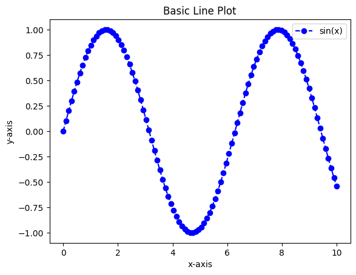

```python
x = np.linspace(0, 10, 100)
y = np.sin(x)

plt.plot(x, y, label="sin(x)", color="blue", linestyle="--", marker="o")
plt.xlabel("x-axis")
plt.ylabel("y-axis")
plt.title("Basic Line Plot")
plt.legend()
plt.show()
```

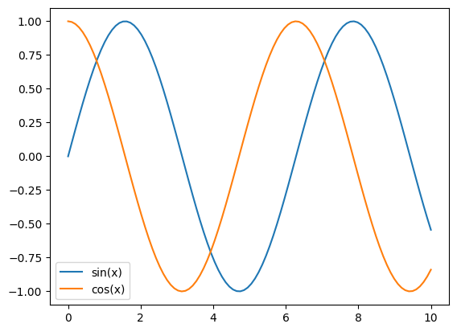

```python
y2 = np.cos(x)

# Multiple lines
plt.plot(x, y, label="sin(x)")
plt.plot(x, y2, label="cos(x)")
plt.legend()
plt.show()
```

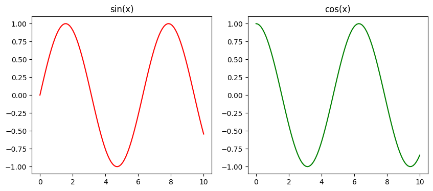

```python
# Subplots
fig, axes = plt.subplots(1, 2, figsize=(10,4))
axes[0].plot(x, y, color="red")
axes[0].set_title("sin(x)")
axes[1].plot(x, y2, color="green")
axes[1].set_title("cos(x)")
plt.show()
```

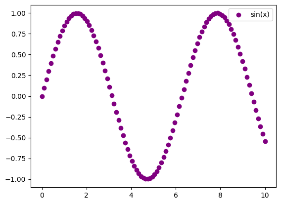

```python
# Scatter
plt.scatter(x, y, color="purple", label="sin(x)")
plt.legend()
plt.show()
```

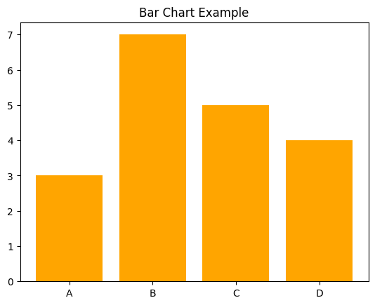

```python
# Bar chart
categories = ["A", "B", "C", "D"]
values = [3, 7, 5, 4]
plt.bar(categories, values, color="orange")
plt.title("Bar Chart Example")
plt.show()
```

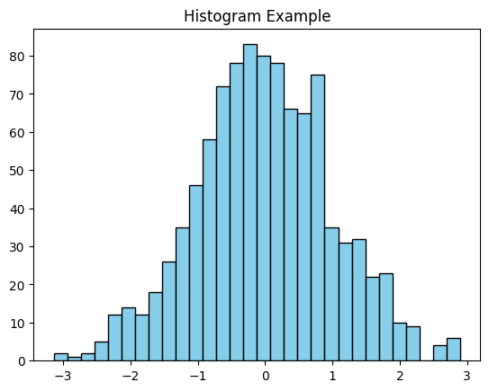

```python
# Histogram
data = np.random.randn(1000)
plt.hist(data, bins=30, color="skyblue", edgecolor="black")
plt.title("Histogram Example")
plt.show()
```

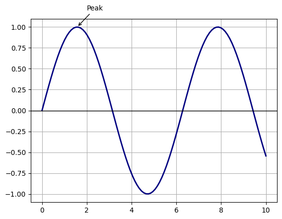

```python
plt.plot(x, y, color="navy", linewidth=2)
plt.grid(True)
plt.axhline(0, color="black", linewidth=1)
plt.annotate("Peak", xy=(np.pi/2, 1), xytext=(2, 1.2),
      arrowprops=dict(facecolor='black', arrowstyle="->"))
plt.show()
```

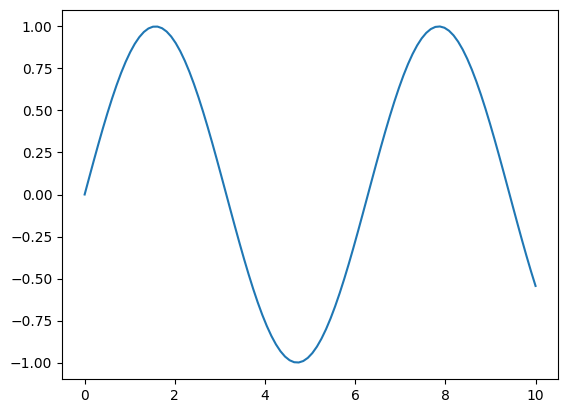

```python
plt.plot(x, y)
plt.savefig("my_plot.png", dpi=300, bbox_inches="tight")
plt.show()
```

# Polynomial interpolation

We create two vectors for data about the population of China. The first has the years of census data and the other has the population, in millions of people.

```python
year = np.arange(1980, 2020, 10)   # from 1980 to 2020 by 10
pop = np.array([984.736, 1148.364, 1263.638, 1330.141])
```

It’s convenient to measure time in years since 1980.

```python
t = year - 1980
y = pop
```

Now we have four data points and we seek an interpolating cubic polynomial. We construct the associated Vandermonde matrix:

```python
V = np.vander(t)
print(V)
```

```
[[    0     0     0     1]
 [ 1000   100    10     1]
 [ 8000   400    20     1]
 [27000   900    30     1]]
```

Solve linear system Vc=y

```python
c = np.linalg.solve(V, y)
print(c)
```

```
[-6.95000e-05 -2.39685e-01  1.87666e+01  9.84736e+02]
```

```python
print(y - V @ c)
```

```
[0. 0. 0. 0.]
```

By our definitions, the coefficients in c are given in descending order of power in t t. We can use the resulting polynomial to estimate the population of China in 2005:

```python
p = np.poly1d(c)          # construct a polynomial
print(p(2005 - 1980))     # apply the 1980 time shift
```

```
1303.0119375
```

The official figure was 1303.72, so our result is rather good.

We can visualize the interpolation process. First, we plot the data as points. Then we add a plot of the interpolant, taking care to shift the t t variable back to actual years.

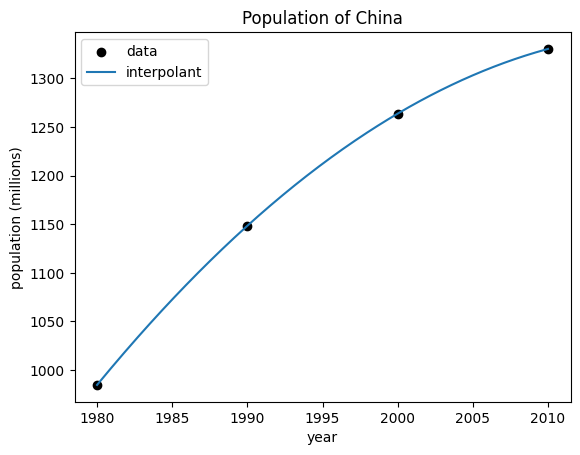

```python
plt.scatter(year, y, color="k", label="data");
tt = np.linspace(0, 30, 300)   # 300 times from 1980 to 2010
plt.plot(1980 + tt, p(tt), label="interpolant");
plt.xlabel("year");
plt.ylabel("population (millions)");
plt.title("Population of China");
plt.legend();
```

# Linear systems

```python
def forwardsub(L,b):
  """
  forwardsub(L,b)

  Solve the lower-triangular linear system with matrix L and right-hand side
  vector b.
  """
  n = len(b)
  x = np.zeros(n)
  for i in range(n):
    s = L[i,:i] @ x[:i]
    x[i] = ( b[i] - s ) / L[i, i]
  return x
def backsub(U,b):
  """
  backsub(U,b)

  Solve the upper-triangular linear system with matrix U and right-hand side
  vector b.
  """
  n = len(b)
  x = np.zeros(n)
  for i in range(n-1, -1, -1):
    s = U[i, i+1:] @ x[i+1:]
    x[i] = ( b[i] - s ) / U[i, i]
  return x
```

```python
np.random.seed(0)
A = 1 + np.floor(9 * np.random.rand(5, 5))
L = np.tril(A)
print(L)
```

```
[[5. 0. 0. 0. 0.]
 [6. 4. 0. 0. 0.]
 [8. 5. 6. 0. 0.]
 [1. 1. 8. 8. 0.]
 [9. 8. 5. 8. 2.]]
```

We’ll set up and solve a linear system with this matrix.

```python
b = np.ones(5)
x = forwardsub(L, b)
print(x)
```

```
[ 0.2        -0.05       -0.05833333  0.16458333 -0.7125    ]
```

It’s not clear how accurate this answer is.

```python
b - L @ x
```

```
array([0.00000000e+00, 0.00000000e+00, 0.00000000e+00, 1.11022302e-16,
       0.00000000e+00])
```

Next we’ll engineer a problem to which we know the exact answer.

```python
alpha = 0.3;
beta = 2.2;
U = np.diag(np.ones(5)) + np.diag([-1, -1, -1, -1], k=1)
U[0, 3:5] = [ alpha - beta, beta ]
print(U)
```

```
[[ 1.  -1.   0.  -1.9  2.2]
 [ 0.   1.  -1.   0.   0. ]
 [ 0.   0.   1.  -1.   0. ]
 [ 0.   0.   0.   1.  -1. ]
 [ 0.   0.   0.   0.   1. ]]
```

```python
x_exact = np.ones(5)
b = np.array([alpha, 0, 0, 0, 1])
x = backsub(U, b)
print("error:", x - x_exact)
```

```
error: [2.22044605e-16 0.00000000e+00 0.00000000e+00 0.00000000e+00
 0.00000000e+00]
```

Everything seems OK here. But another example, with a different value for β, is more troubling.

```python
alpha = 0.3;
beta = 1e12;
U = np.diag(np.ones(5)) + np.diag([-1, -1, -1, -1], k=1)
U[0, 3:5] = [ alpha - beta, beta ]
b = np.array([alpha, 0, 0, 0, 1])

x = backsub(U, b)
print("error:", x - x_exact)
```

```
error: [-4.8828125e-05  0.0000000e+00  0.0000000e+00  0.0000000e+00
  0.0000000e+00]
```

It’s not so good to get 4 digits of accuracy after starting with sixteen! But the source of the error is not hard to track down.